# Lab 1

### David Wilson ● dwils152@uncc.edu

## Consider a “loaded” die that has a 10% chance of getting a 1-5 and a 50% chance of getting a 6.

### 1) What is the mean and variance for the loaded dice?

P(1) = 0.1, P(2) = 0.1, P(3) = 0.1, P(4) = 0.1, P(5) = 0.1, P(6) = 0.5

$$\mu=\sum_{i=1}^{n} p_ix_i~$$

```r
mu <- (1 * 0.1) + (2 * 0.1) + (3 * 0.1) + (4 * 0.1) + (5 * 0.1) + (6 * 0.5)

print(mu)
```

```
## [1] 4.5
```

$$Var(X) = \sum_{i=1}^{n} p_i \cdot (x_i - \mu)^2~$$

```r
var = (0.1 * (1-mu)^2) + (0.1 * (2-mu)^2) + (0.1 * (3-mu)^2) + (0.1 * (4-mu)^2) + (0.1 * (5-mu)^2) + (0.5 * (6-mu)^2)

print(var)
```

```
## [1] 3.25
```

### 2) Make a function in R that “rolls” this dice; return a vector containing the rolls.

###### So if I call: myRolls <- rollLoadedDie(10000), I would get a vector of size 10,000 that contains the rolls of my loaded die.

```r
rollLoadedDie <- function(num_rolls) {

  die <- c(1, 2, 3, 4, 5, 6)
  return(sample(die, size=num_rolls, replace=T, prob=c(0.1, 0.1, 0.1, 0.1, 0.1, 0.5)))

}
```

### 3) Make a histogram of some large number of rolls. Do the rolls of the loaded die approximate a uniform distribution?

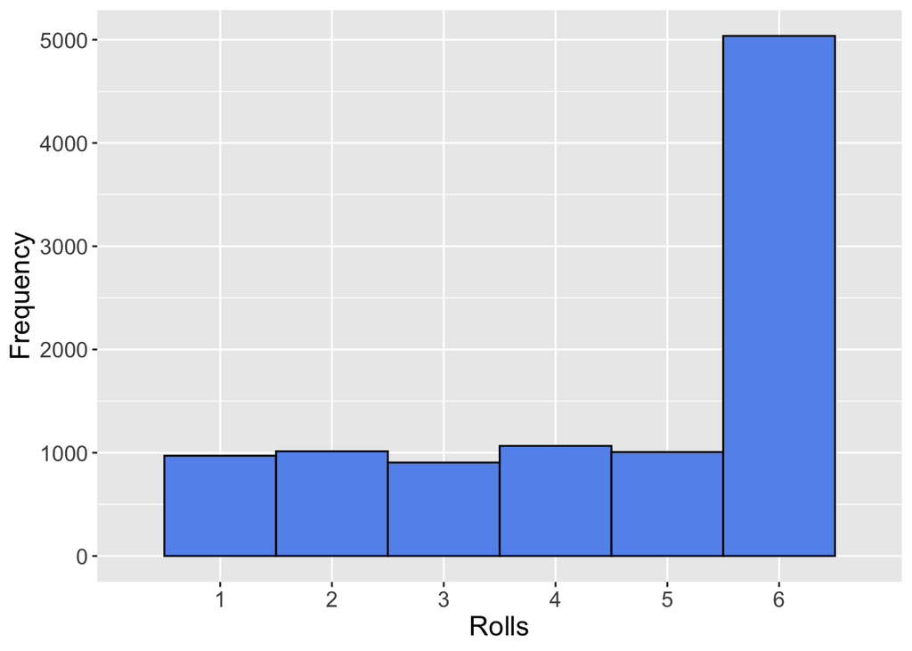

```r
library(ggplot2)
df <- data.frame(rollLoadedDie(10000))
names(df) <- 'Rolls'
ggplot(data=df, aes(x=Rolls)) + geom_histogram(bins=6, color="black", fill="cornflowerblue") + theme(text = element_text(size=15)) + ylab("Frequency") + scale_x_discrete(limits=1:6) #use continuous?
```

The distribution of 10,000 rolls does not approximate the uniform distribution because the die is biased – there is not an equal probability rolling every value in the sample space.

### 4) Modify the code on Slide #58 of lecture #2 so that the means vs. trial size plots are from the loaded die. Generate these plots a few times. How many rolls appear to be necessary to get convergence on the expected values for the mean and variance?

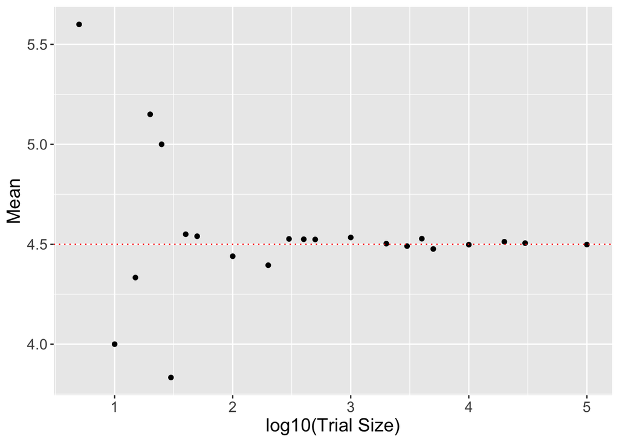

```r
trial_sizes <- c(5, 10, 15, 20, 25, 30, 40, 50, 100, 200, 300, 400, 500, 1000, 2000, 3000, 4000, 5000, 10000, 20000, 30000, 100000)
means <- vector(mode="double", length=length(trial_sizes))
variances <- vector(mode="double", length=length(trial_sizes))

for ( i in 1:length(trial_sizes) ) {

  rolls <- rollLoadedDie(trial_sizes[i])
  means[i] <- mean(rolls)
  variances[i] <- var(rolls)

}

df2 <- data.frame(trial_sizes, means, variances)
ggplot(df2, aes(x=log10(trial_sizes), y=means)) + geom_point() + theme(text = element_text(size=15)) + geom_hline(yintercept=4.5, linetype="dotted", color="red") + xlab("log10(Trial Size)") + ylab("Mean")
```

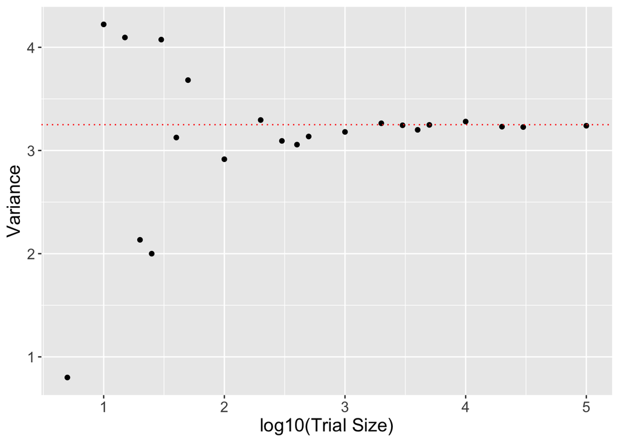

```r
ggplot(df2, aes(x=log10(trial_sizes), y=variances)) + geom_point() + theme(text = element_text(size=15)) + geom_hline(yintercept=3.25, linetype="dotted", color="red") + xlab("log10(Trial Size)") + ylab("Variance")
```

It takes about 1000 rolls for the mean and variance of the sample to converge to their expected value.